# Assignment modue no 7 In R

Why we are doing this as can we remove any similar colinear variable existed in this model lets do this

```r
vif(model1) # as we can see which variable is hurdle in colinearity factor over  here
```

**WT**

603.032816685317

**SP**

17.1107833890901

**VOL**

602.75063936754

**HP**

16.9936712862974

```r
VIFWT<-lm(WT~VOL+HP+SP) # checking wheathe weight is contributing in colinearity
summary(VIFWT) # yes we can see it is showing r square value is best and it is highly co-related
```

```
Call:
lm(formula = WT ~ VOL + HP + SP)

Residuals:
     Min       1Q   Median       3Q      Max
-0.56581 -0.25193  0.07088  0.23244  0.51044

Coefficients:
             Estimate Std. Error t value Pr(>|t|)
(Intercept) -1.882166   0.979497  -1.922   0.0584 .
VOL          0.335519   0.001529 219.396   <2e-16 ***
HP          -0.003148   0.002615  -1.204   0.2322
SP           0.012563   0.010553   1.190   0.2375
---
Signif. codes:  0 '***' 0.001 '**' 0.01 '*' 0.05 '.' 0.1 ' ' 1

Residual standard error: 0.302 on 77 degrees of freedom
Multiple R-squared:  0.9984,	Adjusted R-squared:  0.9984
F-statistic: 1.639e+04 on 3 and 77 DF,  p-value: < 2.2e-16
```

```r
VIFVOL<-lm(VOL~WT+HP+SP)
summary(VIFV)
```

[output not shown]

Here we find the same problem with voume it is also highly related as adjusted R square value is showing 99 % so we have to drop one un related variable from it as it is same impact multicolinearity in the sence

```r
VIFHP<-lm(HP~VOL+WT+SP)
summary(VIFHP)
```

```
Call:
lm(formula = HP ~ VOL + WT + SP)

Residuals:
    Min      1Q  Median      3Q     Max
-25.785 -10.988   0.561   7.634  45.697

Coefficients:
             Estimate Std. Error t value Pr(>|t|)
(Intercept) -359.1891    14.1176 -25.443   <2e-16 ***
VOL            1.9137     1.6380   1.168    0.246
WT            -5.8704     4.8754  -1.204    0.232
SP             3.9323     0.1034  38.045   <2e-16 ***
---
Signif. codes:  0 '***' 0.001 '**' 0.01 '*' 0.05 '.' 0.1 ' ' 1

Residual standard error: 13.04 on 77 degrees of freedom
Multiple R-squared:  0.9498,	Adjusted R-squared:  0.9479
F-statistic: 485.8 on 3 and 77 DF,  p-value: < 2.2e-16
```

likely HP variable also showing 94% increased or influsing factor in our model, we have to take but related variable not similar variable which is unnecessaryly will increase colinearity

```r
VIFSP<-lm(SP~VOL+HP+WT)
summary(VIFSP)
```

```
Call:
lm(formula = SP ~ VOL + HP + WT)

Residuals:
     Min       1Q   Median       3Q      Max
-10.1319  -1.4441  -0.2547   2.7924   6.2470

Coefficients:
             Estimate Std. Error t value Pr(>|t|)
(Intercept) 92.560454   1.964324  47.121   <2e-16 ***
VOL         -0.465851   0.406019  -1.147    0.255
HP           0.241460   0.006347  38.045   <2e-16 ***
WT           1.438508   1.208380   1.190    0.238
---
Signif. codes:  0 '***' 0.001 '**' 0.01 '*' 0.05 '.' 0.1 ' ' 1

Residual standard error: 3.232 on 77 degrees of freedom
Multiple R-squared:   0.95,	Adjusted R-squared:  0.9481
F-statistic: 487.9 on 3 and 77 DF,  p-value: < 2.2e-16
```

it is also highly corelated

if we plot against each variable what we already analysed during our primiraly investiation , by corrgram that volume and weight are corealated each other

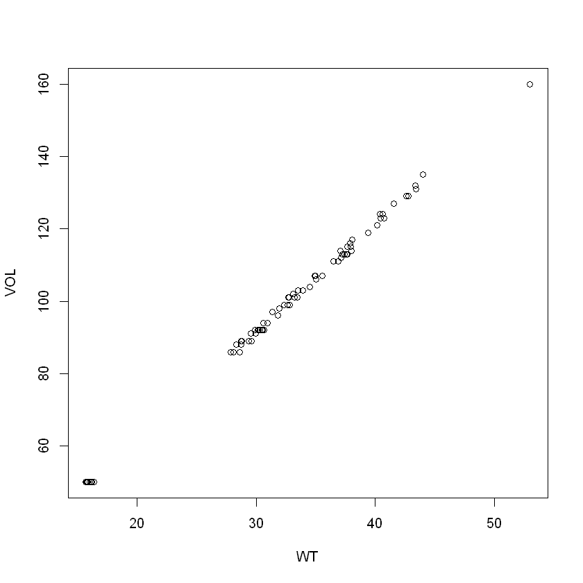

```r
plot(WT,VOL) # we see the volume and weitght how co related with each other
```

we can find multicolinearity by using some techinique in r also some packages available GGally

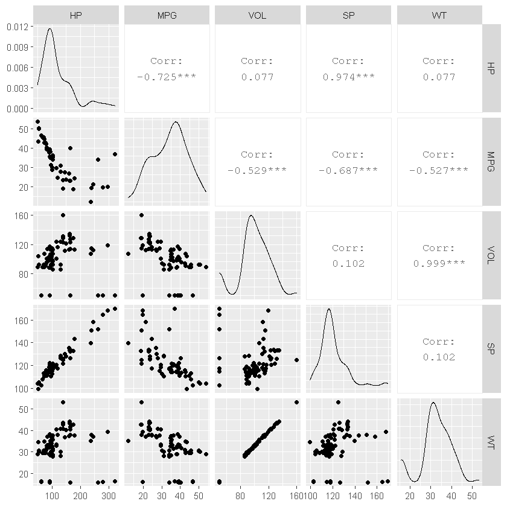

```r
library(GGally)
ggpairs(df)
```

Volume and weight and HP and SP are Highly Corelated with each other very difficult to see and remove corelation variable

To solve this high- colinearity we will use partial-corelation to see the influnsive variabel out

```r
library(corpcor)
```

```r
cor(df)
```

A matrix: 5 × 5 of type dbl

|  | HP | MPG | VOL | SP | WT |
| --- | --- | --- | --- | --- | --- |
| HP | 1.00000000 | -0.7250383 | 0.07745947 | 0.9738481 | 0.07651307 |
| MPG | -0.72503835 | 1.0000000 | -0.52905658 | -0.6871246 | -0.52675909 |
| VOL | 0.07745947 | -0.5290566 | 1.00000000 | 0.1021700 | 0.99920308 |
| SP | 0.97384807 | -0.6871246 | 0.10217001 | 1.0000000 | 0.10243919 |
| WT | 0.07651307 | -0.5267591 | 0.99920308 | 0.1024392 | 1.00000000 |

```r
cor2pcor(cor(df))
```

A matrix: 5 × 5 of type dbl

| 1.00000000 | -0.51507804 | 0.07802551 | 0.9448373 | -0.10251007 |
| --- | --- | --- | --- | --- |
| -0.51507804 | 1.00000000 | -0.06763373 | 0.2756467 | 0.02712318 |
| 0.07802551 | -0.06763373 | 1.00000000 | -0.1056994 | 0.99838084 |
| 0.94483727 | 0.27564673 | -0.10569943 | 1.0000000 | 0.12170021 |
| -0.10251007 | 0.02712318 | 0.99838084 | 0.1217002 | 1.00000000 |

```r
library(car)
```

its a prtiac corelation plot to see added difference between variables

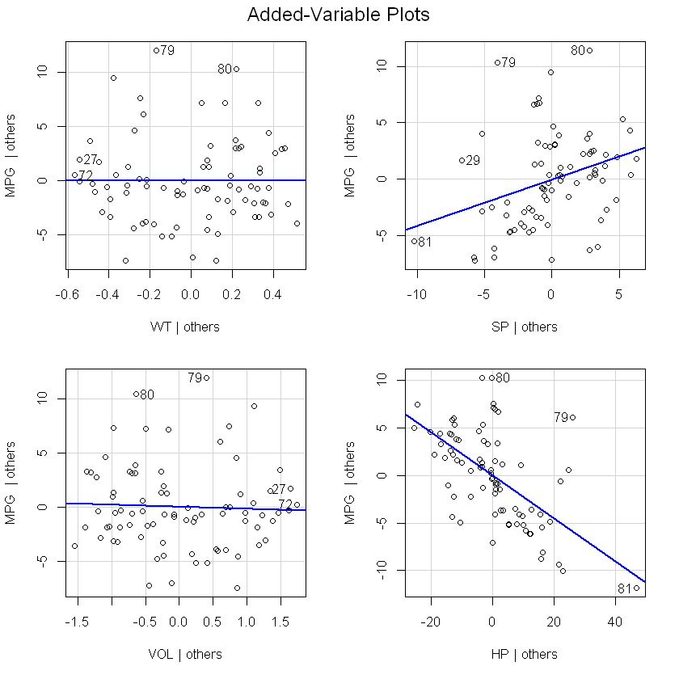

```r
avPlots(model1)
```

[output not shown]

[output cut: 57 more lines]

[output not shown]

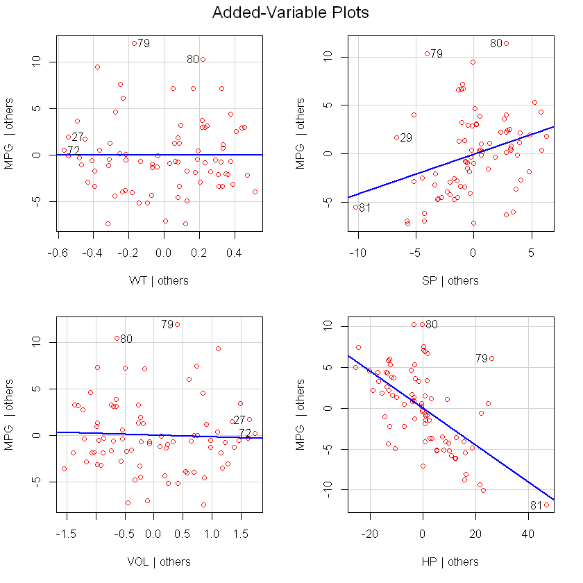

```r
avPlots(model1, id.n=2, id.cex=0.8, col="red")
```

When we having large models to choose out from it we will use this step AIC method

```r
library("MASS")
```

```r
stepAIC(model) # backward
```

```
Start:  AIC=171.15
MPG ~ WT + SP + VOL + HP

       Df Sum of Sq     RSS    AIC
- WT    1      0.21  995.48 169.16
- VOL   1      0.85  996.12 169.20
<none>               995.27 171.15
- SP    1    172.67 1167.94 178.11
- HP    1    505.01 1500.28 192.13

Step:  AIC=169.16
MPG ~ SP + VOL + HP

       Df Sum of Sq     RSS    AIC
<none>               995.48 169.16
- SP    1    173.68 1169.17 176.17
- HP    1    509.51 1505.00 190.31
- VOL   1   1376.60 2372.08 215.79
```

```
Call:
lm(formula = MPG ~ SP + VOL + HP, data = train)

Coefficients:
(Intercept)           SP          VOL           HP
    12.9363       0.5939      -0.2158      -0.2501
```

Step AIC method is saying out to choose our variable which to reject

```r
model.final  <- lm(formula = MPG ~ SP + VOL + HP, data = train)
summary(model.final)
```

```
Call:
lm(formula = MPG ~ SP + VOL + HP, data = train)

Residuals:
     Min       1Q   Median       3Q      Max
-10.1912  -2.4985  -0.8598   1.3282  14.5665

Coefficients:
            Estimate Std. Error t value Pr(>|t|)
(Intercept) 12.93635   18.19857   0.711    0.480
SP           0.59394    0.19719   3.012    0.004 **
VOL         -0.21576    0.02544  -8.480 2.24e-11 ***
HP          -0.25014    0.04849  -5.159 3.94e-06 ***
---
Signif. codes:  0 '***' 0.001 '**' 0.01 '*' 0.05 '.' 0.1 ' ' 1

Residual standard error: 4.375 on 52 degrees of freedom
Multiple R-squared:  0.8025,	Adjusted R-squared:  0.7911
F-statistic: 70.41 on 3 and 52 DF,  p-value: < 2.2e-16
```

[output not shown]

[output cut: 29 more lines]

[output not shown]

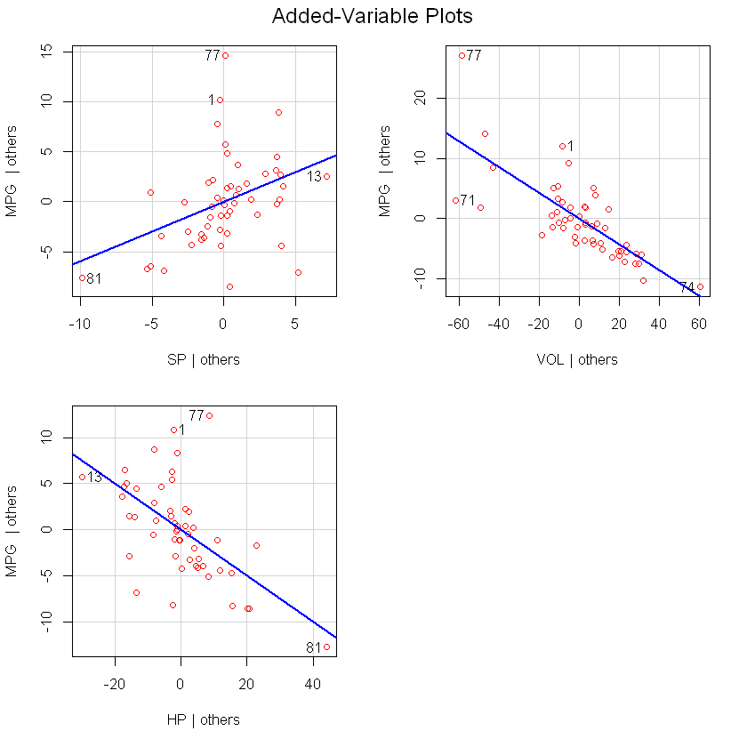

```r
avPlots(model.final, id.n=2, id.cex=0.8, col="red")
```

```r
vif(model.final) # likely we built our final model
```

**SP**

23.7542890473337

**VOL**

1.02747670376812

**HP**

23.6217824178906